# White Wine Quality Exploration

##### by Sarah Aranda

The dataset I’ll be looking at is White Wine Quality. It’s composed of 4,898 observations with 12 variables, including quality which ranges from 0 to 10 (very bad to excellent). The other variables in the dataset are various chemical properties of the wine. A more detailed description of the dataset can be found here: https://s3.amazonaws.com/udacity-hosted-downloads/ud651/wineQualityInfo.txt

### Univariate Plots

I’ll start by getting an idea of the dataset–the variable names, the datatypes, etc.

```
## 'data.frame':    4898 obs. of  13 variables:
##  $ X                   : int  1 2 3 4 5 6 7 8 9 10 ...
##  $ fixed.acidity       : num  7 6.3 8.1 7.2 7.2 8.1 6.2 7 6.3 8.1 ...
##  $ volatile.acidity    : num  0.27 0.3 0.28 0.23 0.23 0.28 0.32 0.27 0.3 0.22 ...
##  $ citric.acid         : num  0.36 0.34 0.4 0.32 0.32 0.4 0.16 0.36 0.34 0.43 ...
##  $ residual.sugar      : num  20.7 1.6 6.9 8.5 8.5 6.9 7 20.7 1.6 1.5 ...
##  $ chlorides           : num  0.045 0.049 0.05 0.058 0.058 0.05 0.045 0.045 0.049 0.044 ...
##  $ free.sulfur.dioxide : num  45 14 30 47 47 30 30 45 14 28 ...
##  $ total.sulfur.dioxide: num  170 132 97 186 186 97 136 170 132 129 ...
##  $ density             : num  1.001 0.994 0.995 0.996 0.996 ...
##  $ pH                  : num  3 3.3 3.26 3.19 3.19 3.26 3.18 3 3.3 3.22 ...
##  $ sulphates           : num  0.45 0.49 0.44 0.4 0.4 0.44 0.47 0.45 0.49 0.45 ...
##  $ alcohol             : num  8.8 9.5 10.1 9.9 9.9 10.1 9.6 8.8 9.5 11 ...
##  $ quality             : int  6 6 6 6 6 6 6 6 6 6 ...
```

```
##        X        fixed.acidity    volatile.acidity  citric.acid
##  Min.   :   1   Min.   : 3.800   Min.   :0.0800   Min.   :0.0000
##  1st Qu.:1225   1st Qu.: 6.300   1st Qu.:0.2100   1st Qu.:0.2700
##  Median :2450   Median : 6.800   Median :0.2600   Median :0.3200
##  Mean   :2450   Mean   : 6.855   Mean   :0.2782   Mean   :0.3342
##  3rd Qu.:3674   3rd Qu.: 7.300   3rd Qu.:0.3200   3rd Qu.:0.3900
##  Max.   :4898   Max.   :14.200   Max.   :1.1000   Max.   :1.6600
##  residual.sugar     chlorides       free.sulfur.dioxide
##  Min.   : 0.600   Min.   :0.00900   Min.   :  2.00
##  1st Qu.: 1.700   1st Qu.:0.03600   1st Qu.: 23.00
##  Median : 5.200   Median :0.04300   Median : 34.00
##  Mean   : 6.391   Mean   :0.04577   Mean   : 35.31
##  3rd Qu.: 9.900   3rd Qu.:0.05000   3rd Qu.: 46.00
##  Max.   :65.800   Max.   :0.34600   Max.   :289.00
##  total.sulfur.dioxide    density             pH          sulphates
##  Min.   :  9.0        Min.   :0.9871   Min.   :2.720   Min.   :0.2200
##  1st Qu.:108.0        1st Qu.:0.9917   1st Qu.:3.090   1st Qu.:0.4100
##  Median :134.0        Median :0.9937   Median :3.180   Median :0.4700
##  Mean   :138.4        Mean   :0.9940   Mean   :3.188   Mean   :0.4898
##  3rd Qu.:167.0        3rd Qu.:0.9961   3rd Qu.:3.280   3rd Qu.:0.5500
##  Max.   :440.0        Max.   :1.0390   Max.   :3.820   Max.   :1.0800
##     alcohol         quality
##  Min.   : 8.00   Min.   :3.000
##  1st Qu.: 9.50   1st Qu.:5.000
##  Median :10.40   Median :6.000
##  Mean   :10.51   Mean   :5.878
##  3rd Qu.:11.40   3rd Qu.:6.000
##  Max.   :14.20   Max.   :9.000
```

Of the variables in the dataset, quality, alcohol, and pH are perhaps the most easily identifiable. The histograms below take a look at their counts.

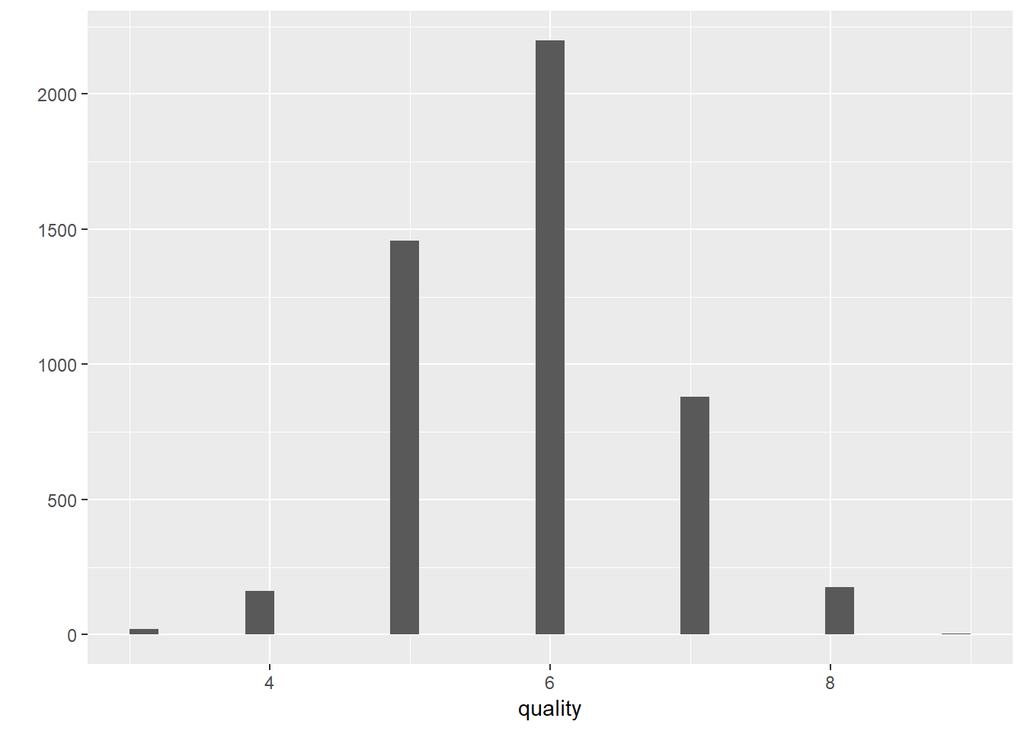

The quality rating is the median of three evaluations made by wine experts who were asked to grade the wine between 0 (very bad) to 10 (very excellent). In the counts histogram above, the most common quality grade is 6 with over 2000 counts. The distribution is a normal curve.

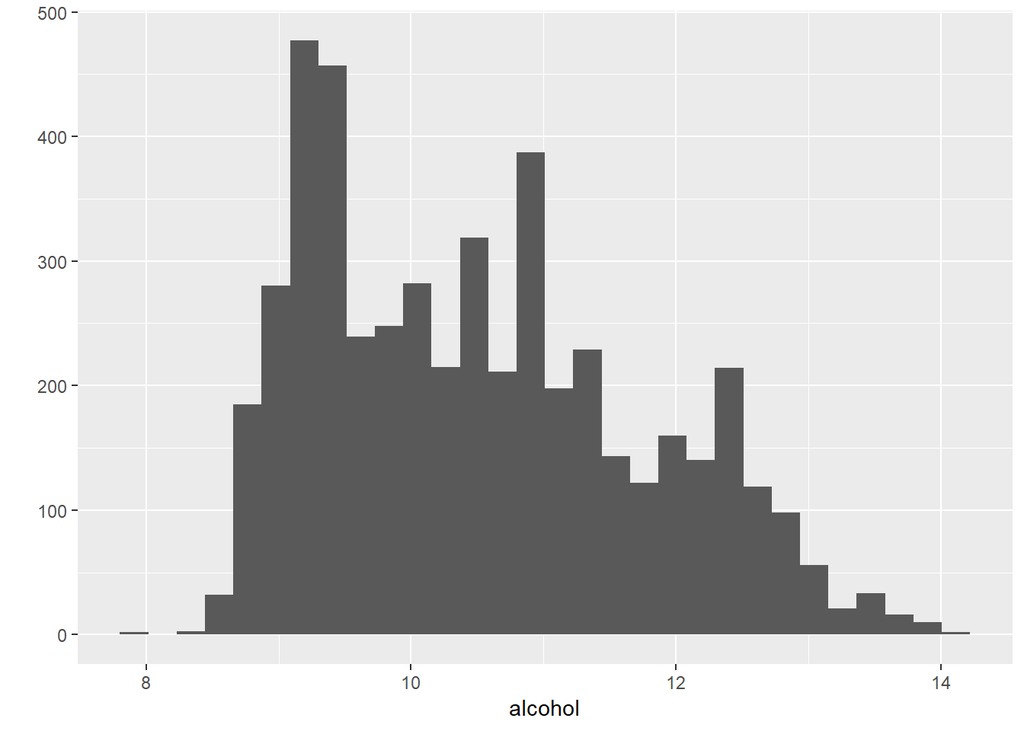

The alcohol variable is the percent alcohol content of the wine. Its counts histogram has roughly three identifiable peaks. The most common percent alcohol content is approximately 9-9.5 percent.

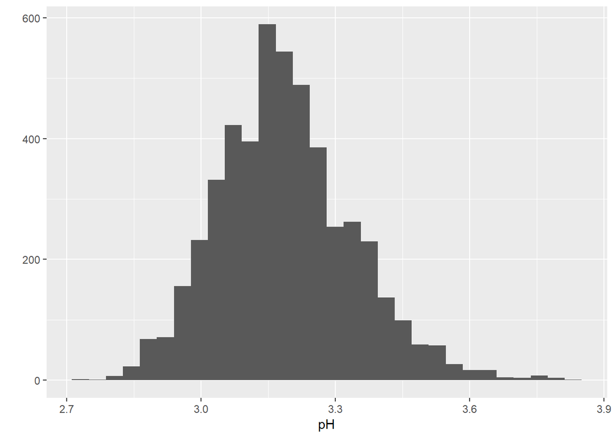

A few other variables which may be interesting to look at and which impact the taste or flavor of the wine include:

1. volatile acidity
2. citric acid
3. residual sugar
4. chlorides

A description of each of these variables, a combined scatter- and boxplot, count histograms, and summary statistics are given below.

#### Volatile Acidity

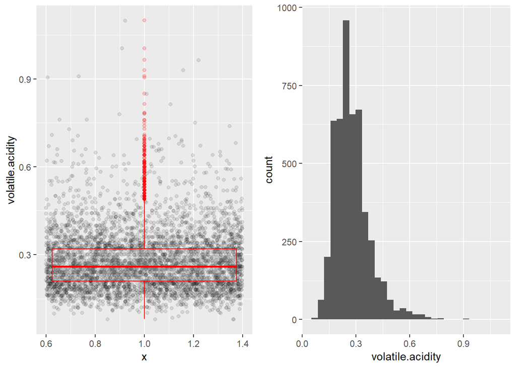

```
##    Min. 1st Qu.  Median    Mean 3rd Qu.    Max.
##  0.0800  0.2100  0.2600  0.2782  0.3200  1.1000
```

Too high levels of volatile acidity can lead to an unpleasant vinegar taste.

In looking at the boxplot for volatile acidity, we see that there are a lot of outliers past 0.45. The plot also confirms the summary statistic of the median at 0.2600 and the interquartile range between 0.2100 and 0.3200. The counts for volatile acidity are right-skewed and sharply peaks at around 0.25.

#### Citric Acid

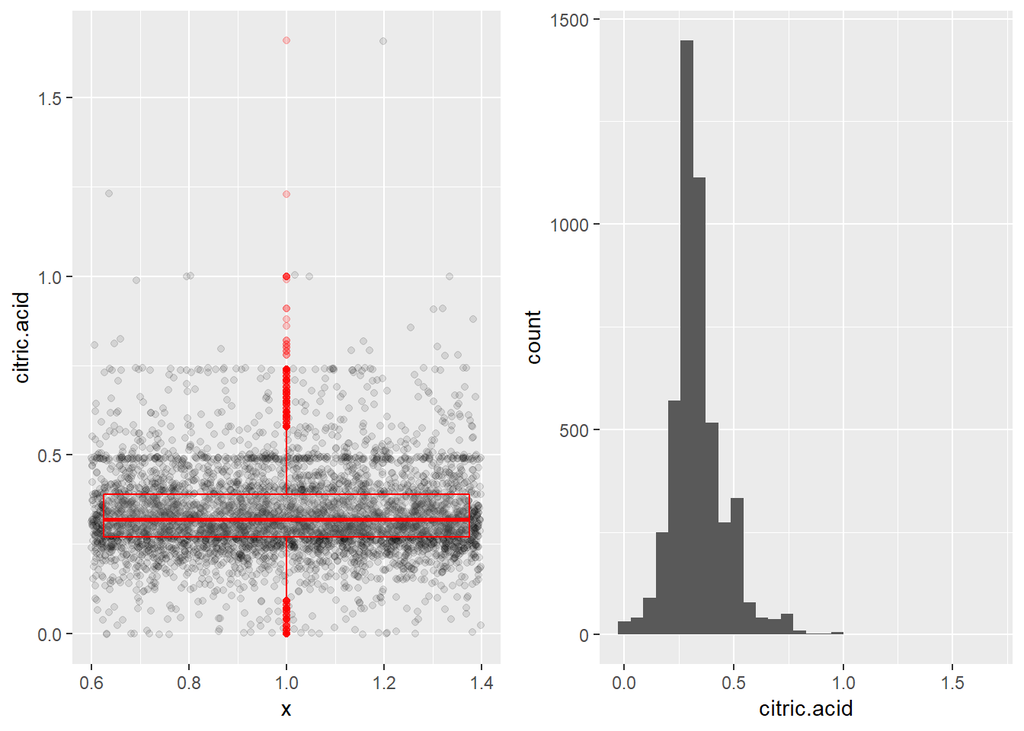

```
##    Min. 1st Qu.  Median    Mean 3rd Qu.    Max.
##  0.0000  0.2700  0.3200  0.3342  0.3900  1.6600
```

Citric acid adds ‘freshness’ to the wine’s flavor.

For the citric acid scatterplot, there is a a wider, darker band where the interquartile range for the boxplots is and interestingly a narrower band just under 0.5 which falls in the upper whisker of the boxplot. The interquartile range is 0.2700 and 0.3900 and the median is 0.3200. As for the histogram, the counts for citric acid are right-skewed and peaks at 0.3.

#### Residual Sugar

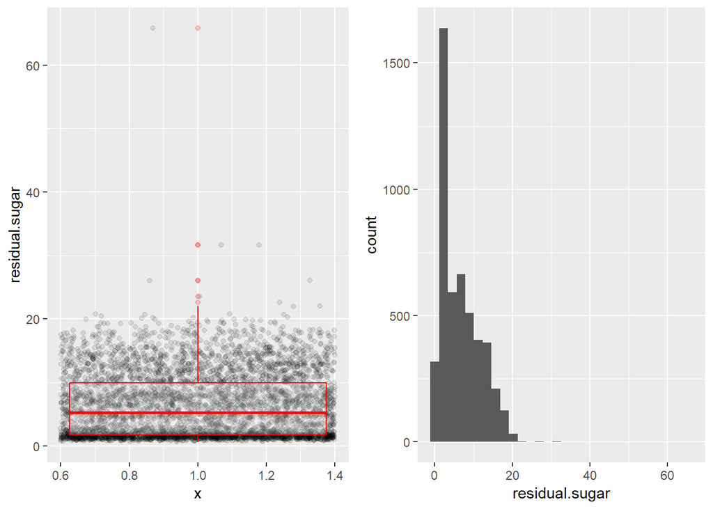

```
##    Min. 1st Qu.  Median    Mean 3rd Qu.    Max.
##   0.600   1.700   5.200   6.391   9.900  65.800
```

Wines with greater than 45 grams/liter of residual sugar are considered sweet.

In the boxplot for residual sugar, there aren’t too many outliers. The interquartile range is between 1.700 to 9.900 and the median is at 5.200. There are a few extreme outliers past 60. The residual sugar histogram is right-skewed and the peak is between 1 and 3.5.

#### Chlorides

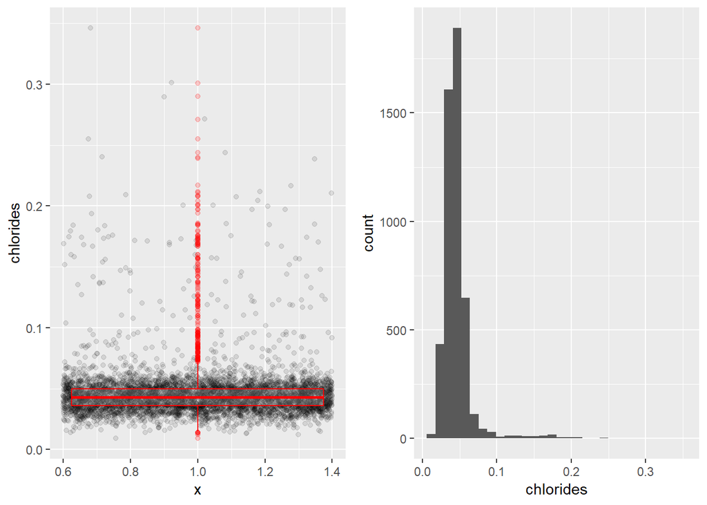

```
##    Min. 1st Qu.  Median    Mean 3rd Qu.    Max.
## 0.00900 0.03600 0.04300 0.04577 0.05000 0.34600
```

Chlorides is the amount of salt in the wine.

The interquartile range for chlorides appears relatively narrow; the first quarter is 0.03600 and the third quarter is 0.05000. The median is 0.04300 . The majority of the outliers are beyond the upper whisker which has a maximum of 0.34600. The histogram for counts is right-skewed and peaks between 0.03 and 0.05.

### Bivariate Plots

In this section, I’ll be looking at bivariate plots. The final set of plots in the previous section were looking specifically at variables that impact the flavor and taste of the wine which I assumed would also impact wine quality. Below is a scatterplot correlation matrix of those variables and also quality.

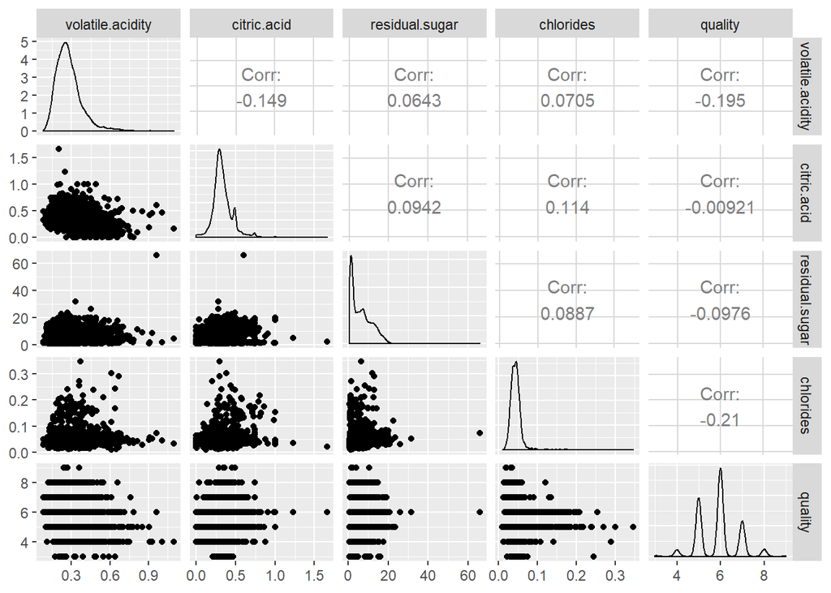

Above, the strongest correlation is a negative one between quality and chlorides which is only a -0.21. In fact, surprisingly, the variables all have weak correlations with quality.

In the univariate section, I had also looked closely at alcohol and pH. A scatterplot correlation matrix is below.

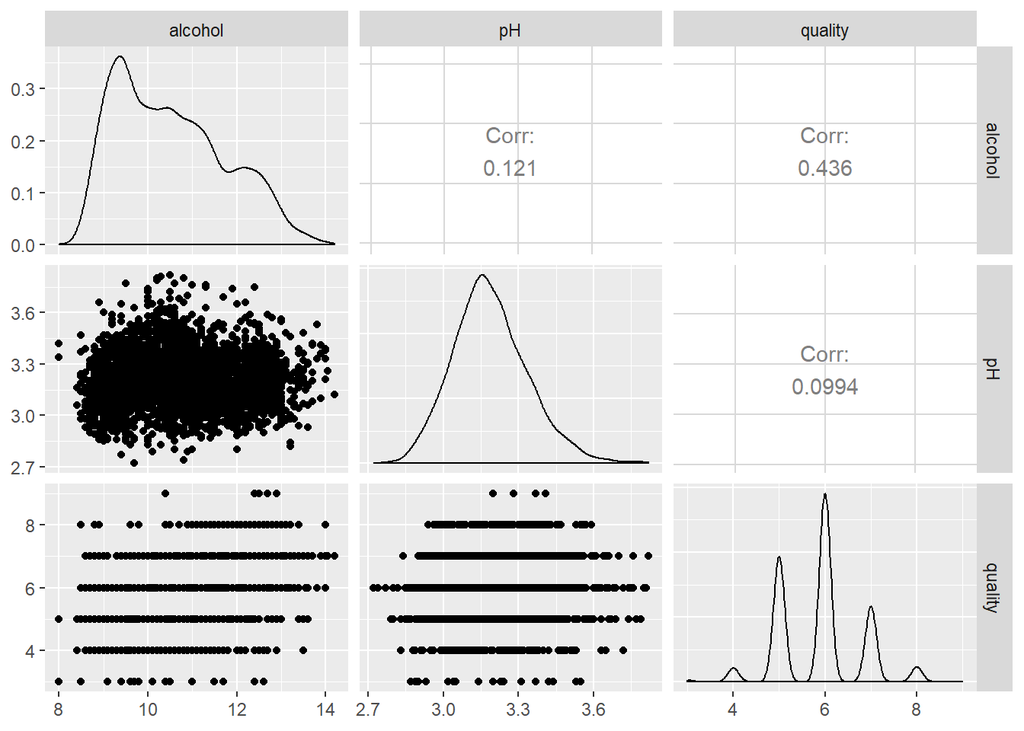

Most of the correlations are weak but there is a moderate correlation between quality and alcohol at 0.43.

To check for correlations across all variables, let’s try the correlation matrix below.

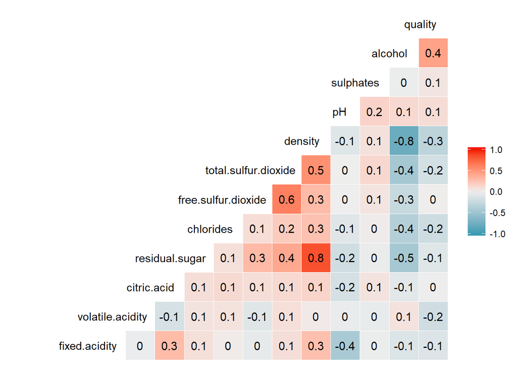

The strongest correlation between quality and another variable is alcohol with a 0.4 (which was discussed earlier). As far as other correlations, the three strongest positive correlations are between residual sugar and density (0.8), free sulfur dioxide and total sulfur dioxide (0.6), and total sulfur dioxide and density (0.5).

According to the description of the data set, free sulfur dioxide prevents microbial growth and the oxidation of wine. A certain level of oxidation is good for wine but too much leads to its degradation (https://vinepair.com/articles/what-is-oxidation-in-wine/). As for the total sulfur dioxide, this measures the free and bound forms of SO2. SO2 is mostly undectable but free SO2 concentrations over 50ppm make it more discernable in the nose and taste of wine.

The two strongest negative correlations are between density and alcohol (-0.8) and alcohol and residual sugar (-0.5).

I’m interested in looking at both the three strongest positive correlations and the two strongest negative correlations (only two since the there are several variables that share the third strongest negative correlation value). Visualizing the data may help us to gain a more detailed understanding of the correlations.

Let’s look first at the three strongest positive correlations:

- density and residual sugar
- free sulfur dioxide and total sulfur dioxide
- density and total sulfur dioxide

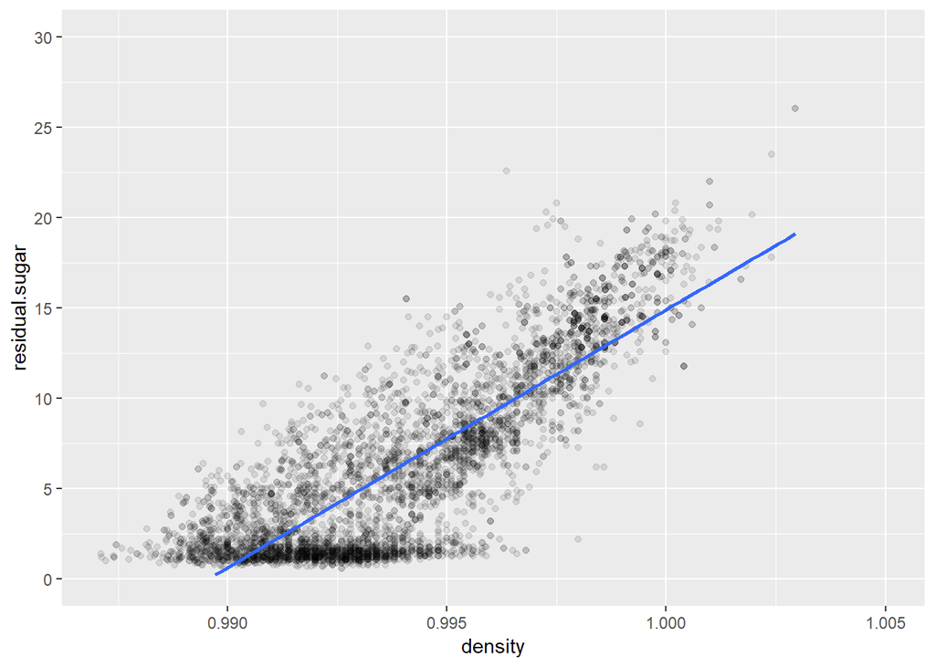

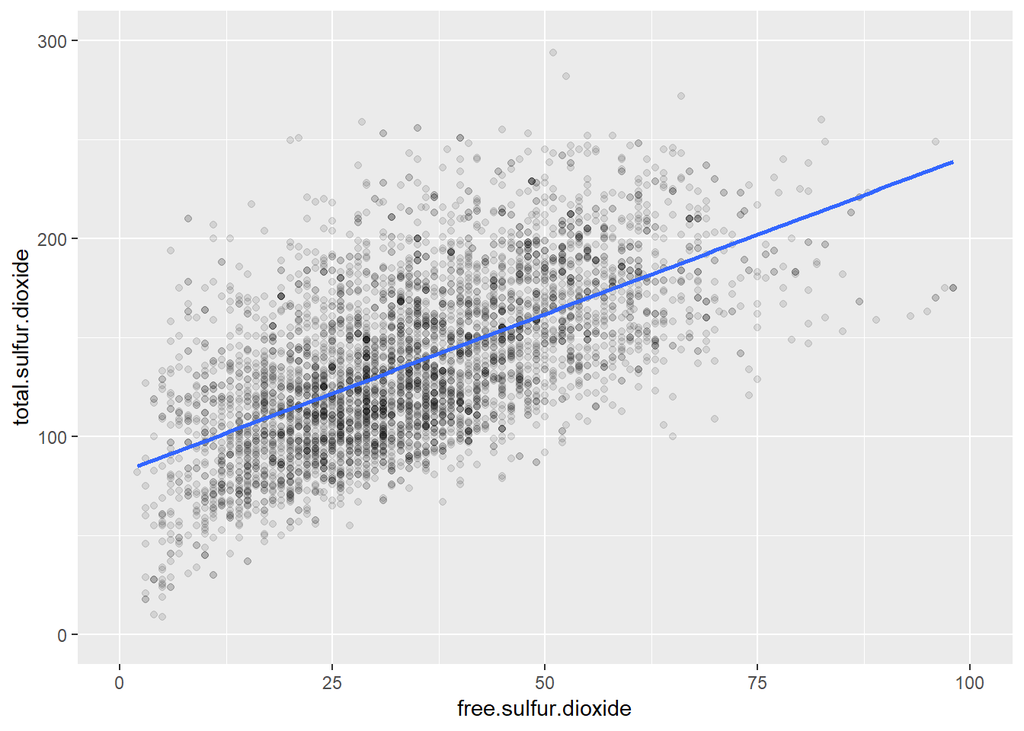

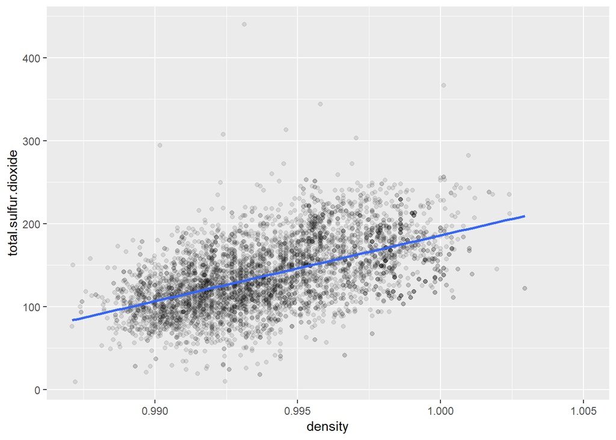

The three plots above confirm what we observed in our correlation matrix. In the density and residual sugar plot, we can also observe a darker horizontal band toward the bottom of the plot where a lot of the observations lie between approximately 1-2.5 residual sugar and a density of between 0.9875 and 0.995.

Now, let’s look at the two strongest negative correlations.

- alcohol and density
- alcohol and residual sugar

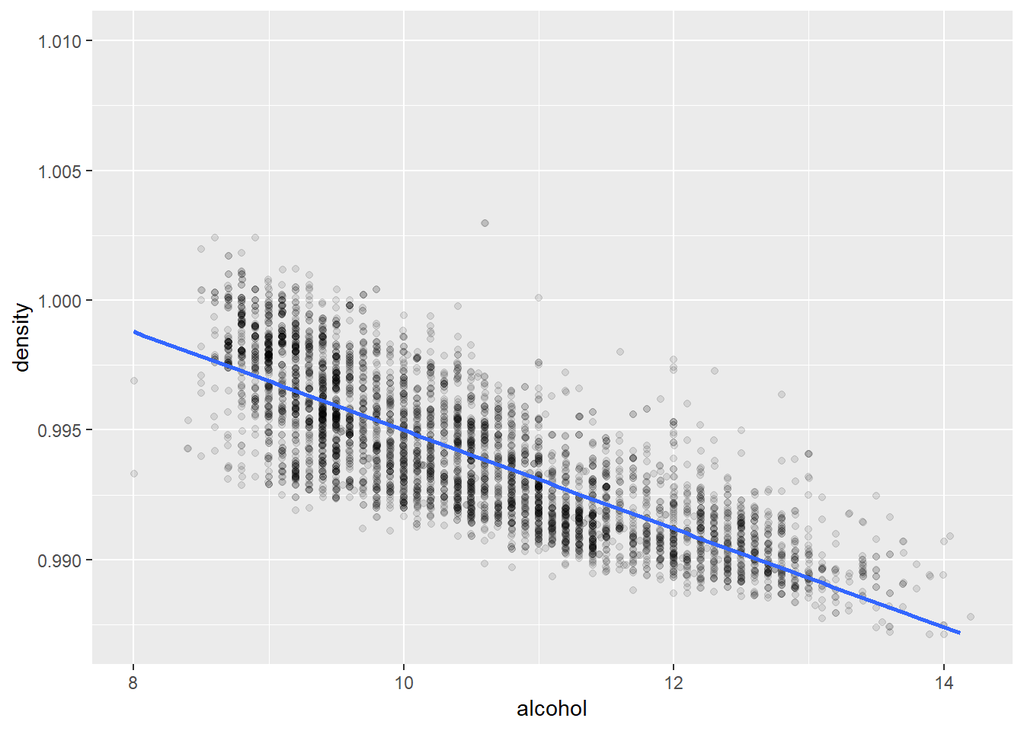

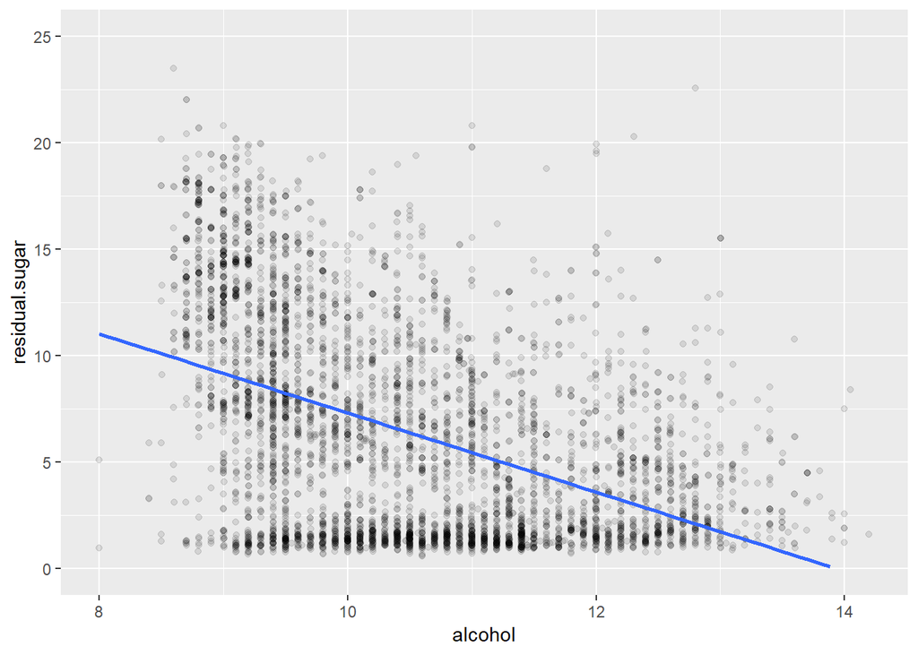

The scatterplots confirm the observations from the correlation matrix. Of the two, the alcohol and density plot has a stronger negative correlation. In the alcohol and residual sugar plot, there seems to be a high concentration of observations below a residual sugar of 2.5 and then what looks a little bit like a horizontal break or gap in the plot where few observations fall (approximately where residual sugar is 2.5).

Additionally, the scatterplots show that the dots are arranged almost into columns which suggests that the values in alcohol may be somewhat discrete. We can use the table function to verify.

```
##
##                8              8.4              8.5              8.6
##                2                3                9               23
##              8.7              8.8              8.9                9
##               78              107               95              185
##              9.1              9.2              9.3              9.4
##              144              199              134              229
##              9.5 9.53333333333333             9.55              9.6
##              228                3                2              128
## 9.63333333333333              9.7 9.73333333333333             9.75
##                1              105                2                1
##              9.8              9.9               10 10.0333333333333
##              136              109              162                1
##             10.1 10.1333333333333            10.15             10.2
##              114                2                3              130
##             10.3             10.4 10.4666666666667             10.5
##               85              153                2              160
## 10.5333333333333            10.55 10.5666666666667             10.6
##                1                2                1              114
##            10.65             10.7             10.8             10.9
##                1               96              135               88
## 10.9333333333333 10.9666666666667            10.98               11
##                2                3                1              158
##            11.05 11.0666666666667             11.1             11.2
##                2                1               83              112
## 11.2666666666667             11.3 11.3333333333333            11.35
##                1              101                3                1
## 11.3666666666667             11.4 11.4333333333333            11.45
##                1              121                1                4
## 11.4666666666667             11.5            11.55             11.6
##                1               88                1               46
## 11.6333333333333            11.65             11.7 11.7333333333333
##                2                1               58                1
##            11.75             11.8            11.85             11.9
##                2               60                1               53
##            11.94            11.95               12            12.05
##                2                1              102                1
## 12.0666666666667             12.1            12.15             12.2
##                1               51                2               86
##            12.25             12.3 12.3333333333333             12.4
##                1               62                1               68
##             12.5             12.6             12.7            12.75
##               83               63               56                3
##             12.8 12.8933333333333             12.9               13
##               54                2               39               36
##            13.05             13.1 13.1333333333333             13.2
##                1               18                1               14
##             13.3             13.4             13.5            13.55
##                7               20               12                1
##             13.6             13.7             13.8             13.9
##                9                7                2                3
##               14            14.05             14.2
##                5                1                1
```

Though there are some odd values, we see that the values for alcohol are relatively discrete.

In the beginning of this analysis the first variables I was most interested in looking at were alcohol, pH, and residual sugar. I’m curious whether higher quality wines would more likely fall within a certain range of these variables.

To carry out this analysis, I categorized the wines into high quality (greater than or equal to 7) or not high quality (less than 7) by introducing a new variable (quality.cat) into the dataset. To make the counts even for both categories, I took a random sample without replacement for both categories (1000 each) and created a new dataset with them.

Frequency polygons for the aforementioned variables and from my sample dataset are below.

```
##         X fixed.acidity volatile.acidity citric.acid residual.sugar
## 4695 4695           6.9             0.19        0.31          19.25
## 1333 1333           7.9             0.16        0.64          17.00
## 3597 3597           6.6             0.17        0.28           1.10
## 3743 3743           7.0             0.15        0.28          14.70
## 2667 2667           5.9             0.34        0.31           2.00
## 3997 3997           6.7             0.28        0.34           8.90
##      chlorides free.sulfur.dioxide total.sulfur.dioxide density   pH
## 4695     0.043                  38                  167 0.99954 2.93
## 1333     0.050                  69                  210 1.00040 3.15
## 3597     0.034                  55                  108 0.98939 3.00
## 3743     0.051                  29                  149 0.99792 2.96
## 2667     0.030                  38                  142 0.98892 3.40
## 3997     0.048                  32                  111 0.99455 3.25
##      sulphates alcohol quality  quality.cat
## 4695      0.52     9.1       7 high quality
## 1333      0.51     9.3       7 high quality
## 3597      0.52    11.9       7 high quality
## 3743      0.39     9.0       7 high quality
## 2667      0.41    12.9       7 high quality
## 3997      0.54    11.0       7 high quality
```

```
##         X fixed.acidity volatile.acidity citric.acid residual.sugar
## 4419 4419           6.6             0.22        0.23          17.30
## 3671 3671           6.2             0.21        0.18          11.60
## 444   444           6.6             0.52        0.44          12.20
## 1755 1755           6.4             0.16        0.28           2.20
## 1708 1708           6.8             0.26        0.29          16.95
## 2217 2217           7.8             0.30        0.37           1.30
##      chlorides free.sulfur.dioxide total.sulfur.dioxide density   pH
## 4419     0.047                  37                  118 0.99906 3.08
## 3671     0.044                  61                  155 0.99655 3.14
## 444      0.048                  54                  245 0.99750 3.26
## 1755     0.042                  33                   93 0.99140 3.31
## 1708     0.056                  48                  179 0.99980 3.45
## 2217     0.051                  16                   96 0.99410 3.32
##      sulphates alcohol quality      quality.cat
## 4419      0.46     8.8       6 not high quality
## 3671      0.52     9.4       6 not high quality
## 444       0.54     9.3       6 not high quality
## 1755      0.43    11.1       6 not high quality
## 1708      0.40     9.6       5 not high quality
## 2217      0.62    10.0       5 not high quality
```

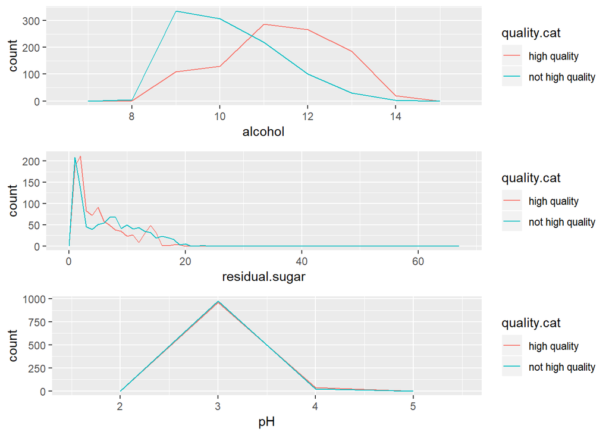

For the plots above, both the high quality and not high quality wines have about the same counts for residual sugar and look to overlap perfectly with pH. These suggest that these factors don’t help to differentiate between high quality and low quality wines. However, for alcohol, we can see a significant difference in counts and where they peak. For high quality wines, the counts peak about 10.5 to 13 alcohol and those of lower quality peak at about 8.5 to 10.5. This corroborates our previous finding that alcohol and quality are correlated.

Let’s take a closer look at the pH and see whether there really is a perfect overlap between the two wine qualities.

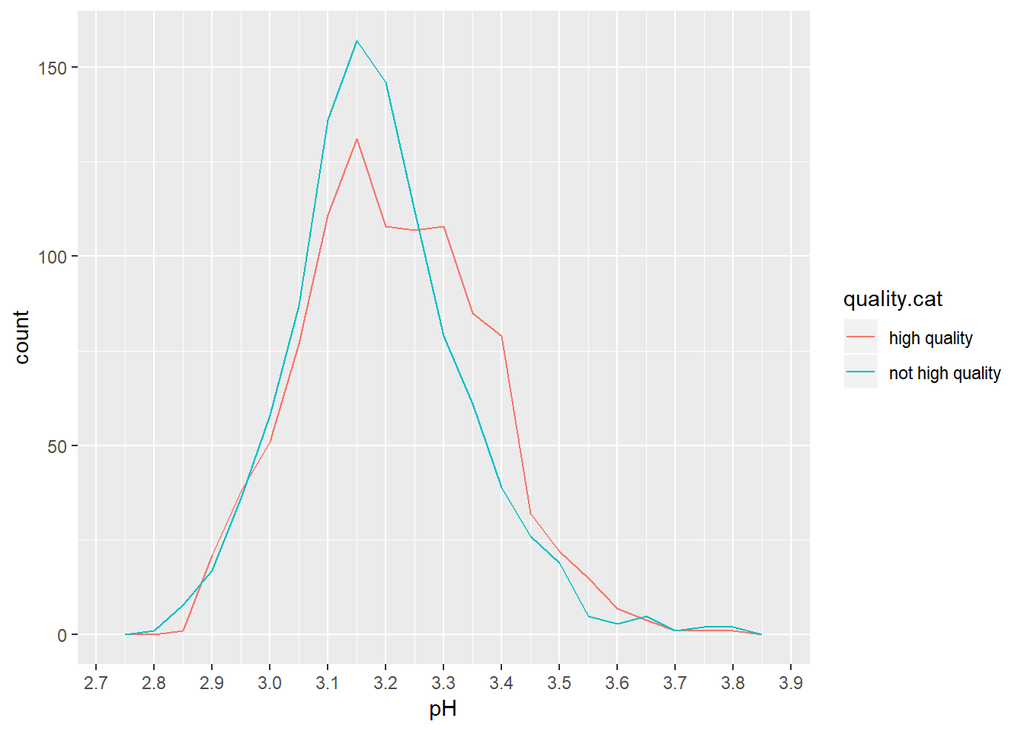

```
##    Min. 1st Qu.  Median    Mean 3rd Qu.    Max.
##   2.840   3.107   3.200   3.215   3.320   3.820
```

```
##    Min. 1st Qu.  Median    Mean 3rd Qu.    Max.
##   2.790   3.090   3.175   3.187   3.270   3.800
```

### Multivariate Plots

From the Bivarite Plots in the previous section, I assumed that a lot of the variables related to taste and flavor would impact the quality of the wine (i.e. have a moderate to strong correlation). However, the analyses above suggest otherwise.

Let’s revisit the plots for our three strongest positive correlations and include quality since that criteria is what I’m most interested in understanding. The quality variable I’ll be using is “high quality” versus “not high quality” (from quality.cat which I created) which will plot an equal number of observations from both categories.

- density and residual sugar
- free sulfur dioxide and total sulfur dioxide
- density and total sulfur dioxide

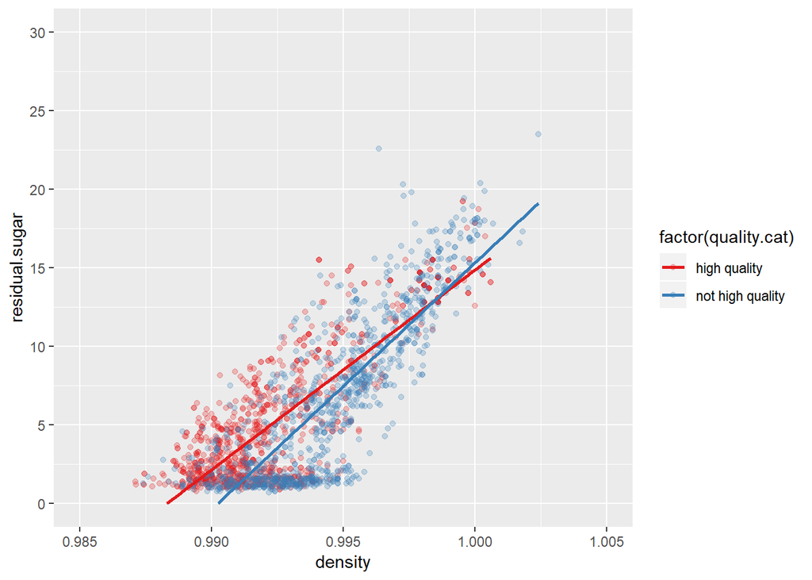

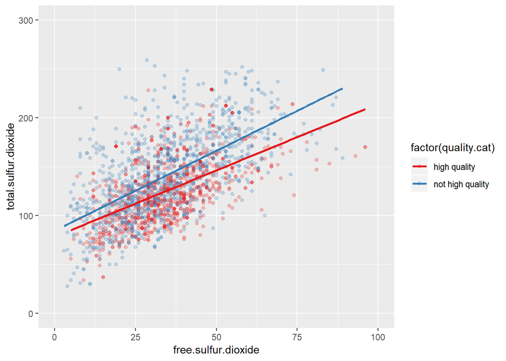

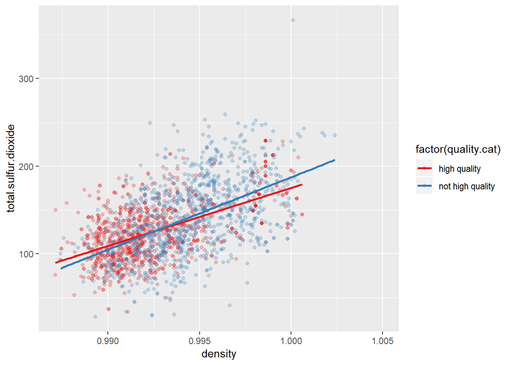

By overlaying the quality categories over the scatterplots we looked at earlier, it becomes clear that there’s not only a relationship between the x and y variables of the three plots above, there also appears to be a relationship between those variables and wine quality.

In the first of the three plots–density and residual sugar–we can see the dots for higher quality wines shifted slightly to the left and not as spread out along the y-axis. For the last of the three plots, we notice that the higher quality values tend to fall in lower ranges for both density and total sulfur dioxide.

Let’s try the plots for the two strongest negative correlations.

- alcohol and density
- alcohol and residual sugar

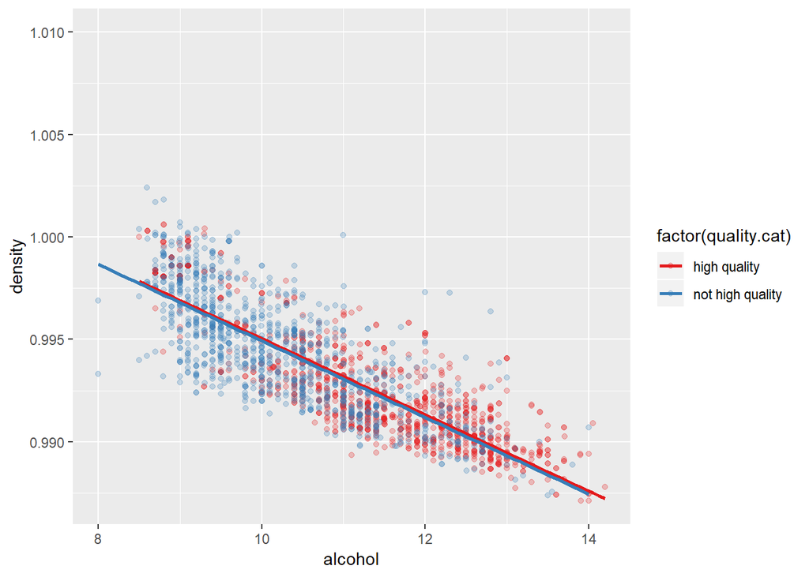

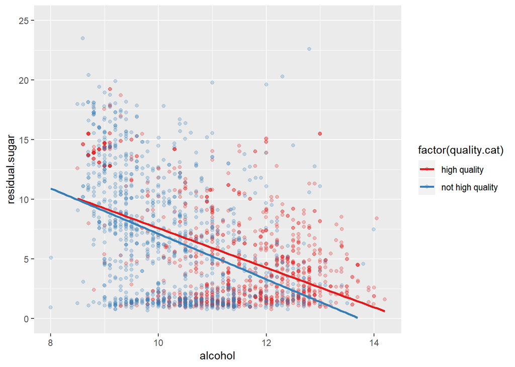

Overlaying the quality categories over the alcohol vs density and alcohol vs residual sugars plots again reveal that differences between higher and lower quality wines within the context of these variables.

I want to look at these plots even more closely, particularly quality. I’ll do this by categorizing the wine qualities into three categories instead of the two we have. The categories will be low (wine qualities 3 and 4), medium (wine qualities 5-6), and high (wine qualities 7-9). In comparing the number of observations across these three categories, low quality wines have the fewest observations (183), therefore, I’ll take a random sample of 183 observations from the three categories for a total of 549 observations in this new sample dataset.

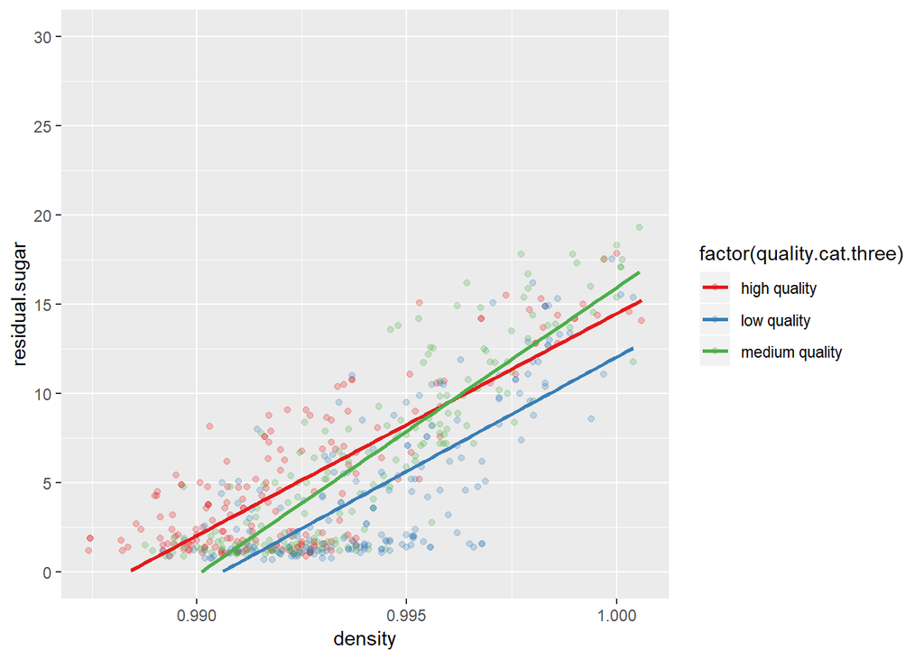

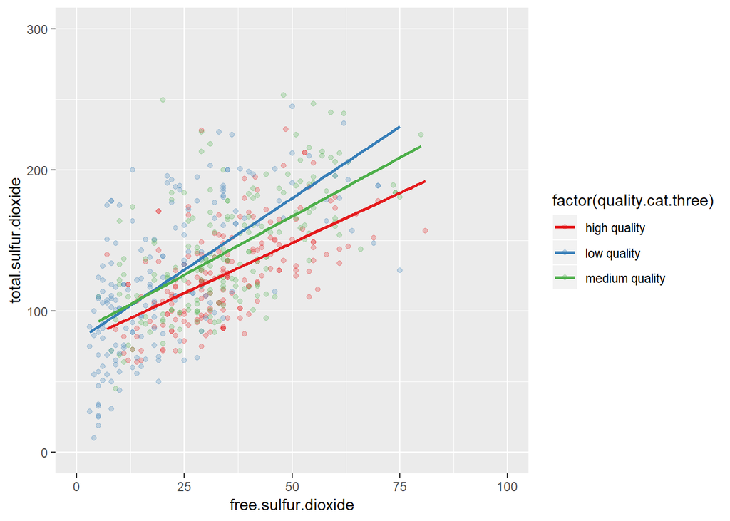

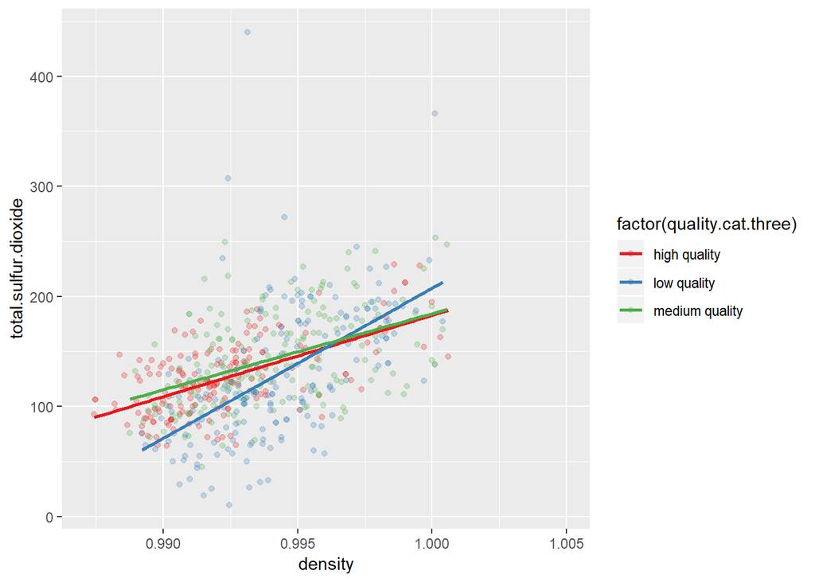

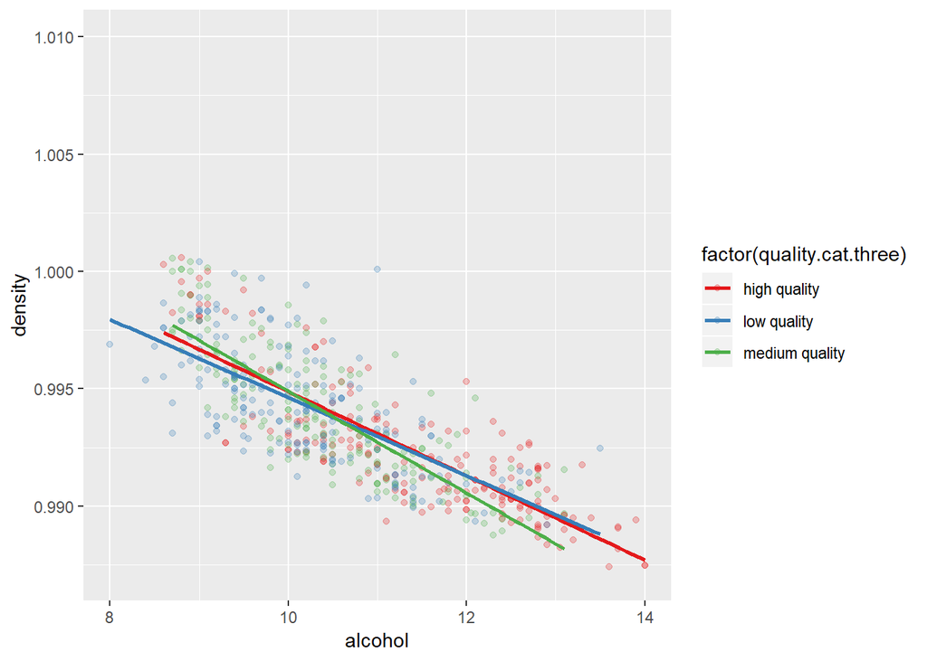

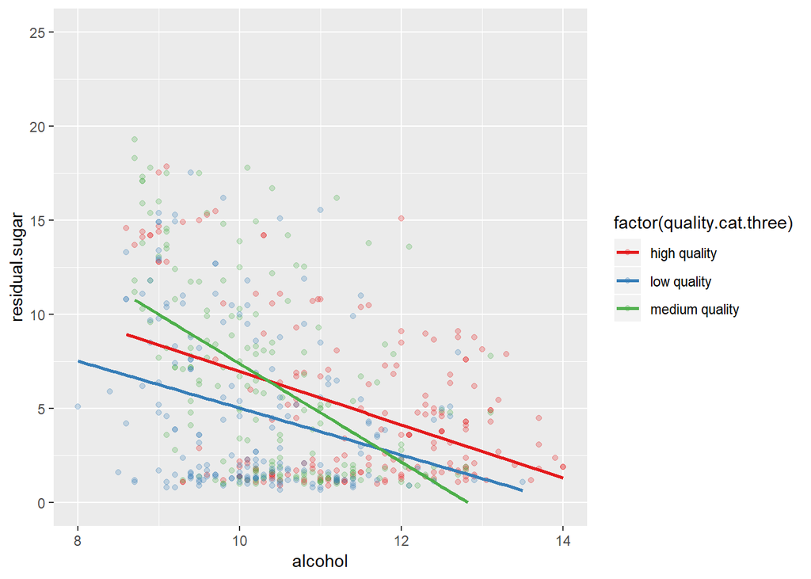

Breaking down the previous scatterplots into three wine qualities, we notice some clear distinctions among the high quality wines (rated 7 and up) versus the low and medium quality wines.

Now, let’s return to the variables related to flavor. The plots below consider the relationship between alcohol (which we know is moderately correlated with quality) and the other variables that impact taste and flavor. For this set of plots, I’m interested in looking at three quality categories I created in my second sample data set.

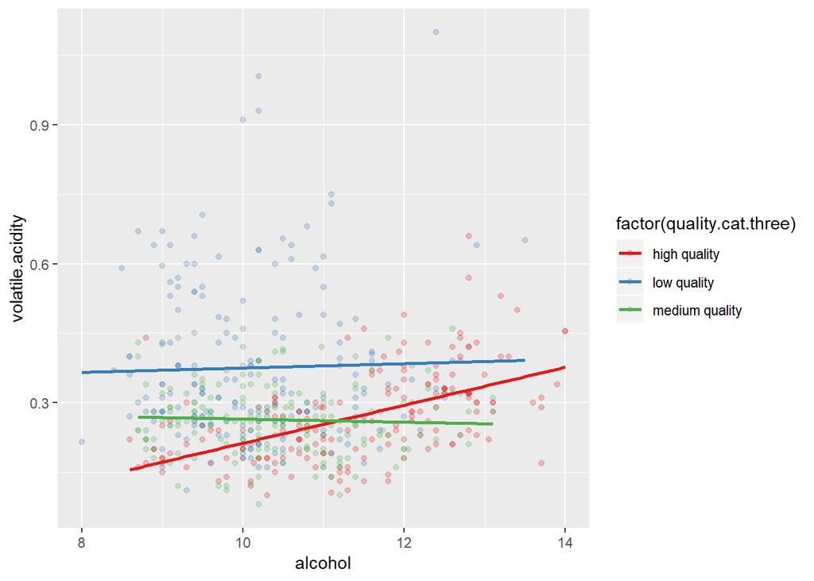

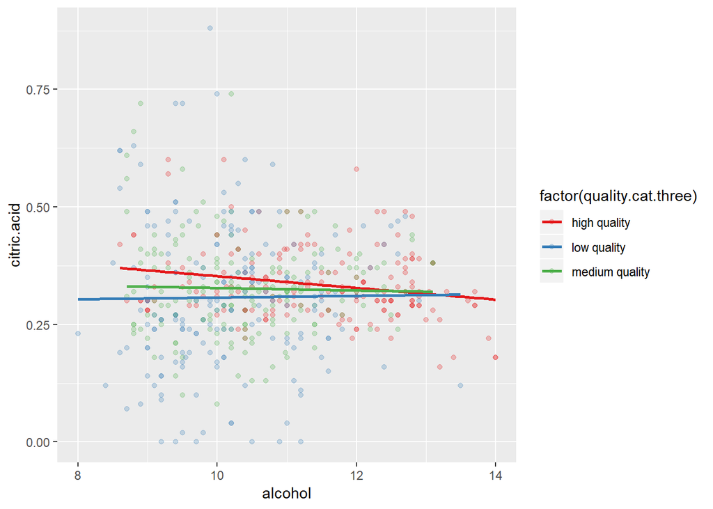

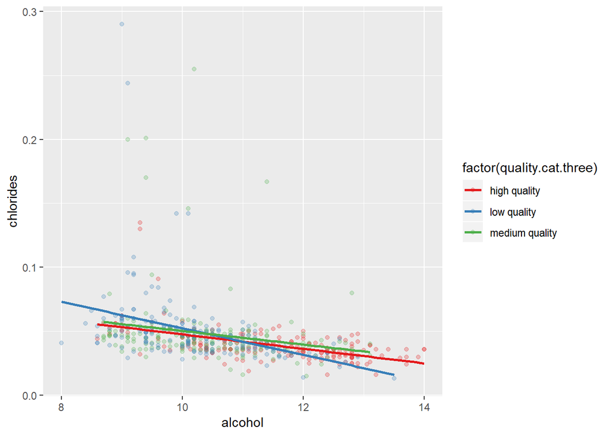

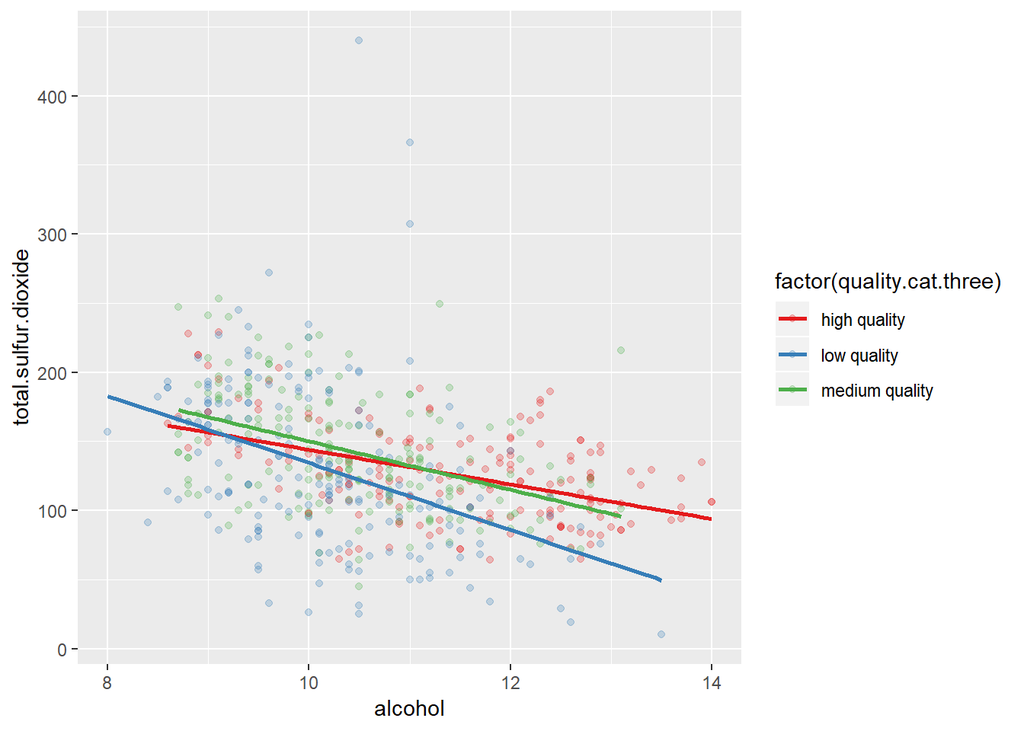

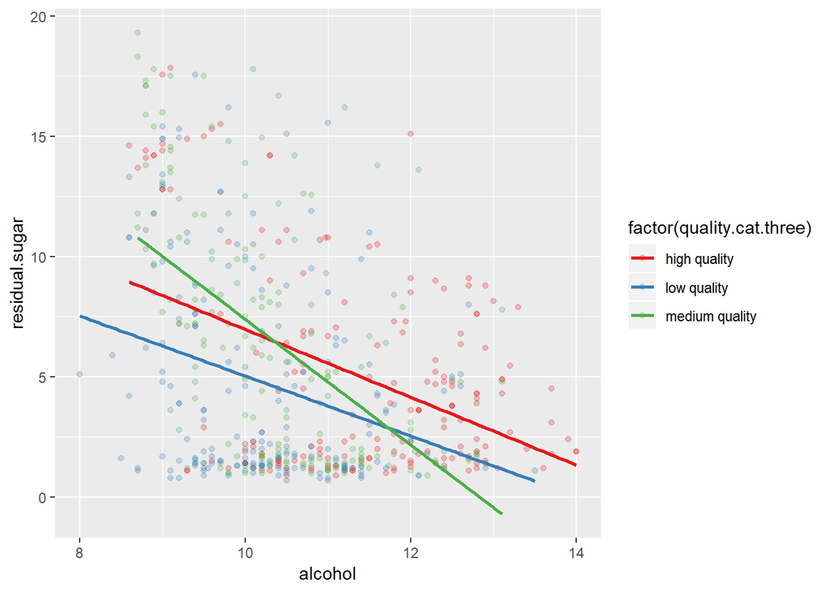